# scATAC-seq lab

```r
library(Signac)
library(Seurat)
library(GenomeInfoDb)
library(EnsDb.Hsapiens.v75)
```

```r
library(ggplot2)
library(patchwork)
library(JASPAR2020)
library(TFBSTools)
library(BSgenome.Hsapiens.UCSC.hg19)
set.seed(1234)
```

### Loading scATAC-seq data

The ATAC-seq data, consists of four files, that are created with CellRanger.

- A count file. The rows are regions (peaks) and the colums are cells. Each entry *i,j* is the number of reads mapping to region *i* in cell *j*.
- A meta data file, with some overall statistics for each cell
- A fragment file, with information on all sequenced fragments (where it maps to the genome, which cell barcode is associated and how many PCR duplicates were found)
- An index file connected to the fragment file. This is like an index file for a bam file, to make it possible to quickly find fragments for a certain genomic region, with having to search the entire file.

Here we create a `ChromatinAssay` object from the count matrix (and a link to the fragment file). This object stores the genomic regions, count data, and also possibly gene annotations and information on sequence motifs. There are many ways to interact with a `ChromatinAssay` object, see [this] (https://satijalab.org/signac/articles/data_structures.html) vignette.

We then create a `Seurat` object from the `ChromatinAssay`, together with meta data about cells and gene annotations.

```r
counts <- Read10X_h5(filename = "atac_v1_pbmc_10k_filtered_peak_bc_matrix.h5")
counts <- counts[, sample(ncol(counts), 2000)] # Only use 2000 cells, to make commands run faster.

metadata <- read.csv(
    file = "atac_v1_pbmc_10k_singlecell.csv",
    header = TRUE,
    row.names = 1
)

chrom_assay <- CreateChromatinAssay(
    counts = counts,
    sep = c(":", "-"),
    genome = 'hg19',
    fragments = 'atac_v1_pbmc_10k_fragments.tsv.gz',
    min.cells = 10,
    min.features = 200
)
```

```
## Computing hash
```

```r
pbmc <- CreateSeuratObject(
    counts = chrom_assay,
    assay = "peaks",
    meta.data = metadata
)
# Extract gene annotations from EnsDb
annotations <- GetGRangesFromEnsDb(ensdb = EnsDb.Hsapiens.v75)
```

```
## Fetching data...
```

```
## OK
```

[output not shown]

[output cut: 119 more lines]

[output not shown]

[output not shown]

[output cut: 13 more lines]

[output not shown]

```r
# Change to UCSC style since the data was mapped to hg19
seqlevelsStyle(annotations) <- 'UCSC'
genome(annotations) <- "hg19"

# Add the gene information to the object
Annotation(pbmc) <- annotations

# Inspect the objects we have created
pbmc
```

```
## An object of class Seurat
## 75396 features across 2000 samples within 1 assay
## Active assay: peaks (75396 features, 0 variable features)
```

```r
pbmc[['peaks']]
```

```
## ChromatinAssay data with 75396 features for 2000 cells
## Variable features: 0
## Genome: hg19
## Annotation present: TRUE
## Motifs present: FALSE
## Fragment files: 1
```

```r
granges(pbmc)
```

```
## GRanges object with 75396 ranges and 0 metadata columns:
##           seqnames            ranges strand
##              <Rle>         <IRanges>  <Rle>
##       [1]     chr1     565113-565543      *
##       [2]     chr1     569179-569635      *
##       [3]     chr1     713534-714806      *
##       [4]     chr1     752436-753020      *
##       [5]     chr1     762144-763353      *
##       ...      ...               ...    ...
##   [75392]     chrY 23410595-23411771      *
##   [75393]     chrY 23418918-23419001      *
##   [75394]     chrY 23422186-23422618      *
##   [75395]     chrY 23584049-23584422      *
##   [75396]     chrY 28816422-28818023      *
##   -------
##   seqinfo: 24 sequences from an unspecified genome; no seqlengths
```

### Quality control

The next step is to do some quality control (QC) on the ATAC-seq data. There are several qualtiy measures to consider:

- **Fragment sizes**, determined from paired-end sequencing data. For each cell we can quantify the fragment sizes by calculaing the ratio of nucleosome size fragments (147-294 nucleotides) to nucleosome-free fragments (<147 nucleotides). Open chromatin correseponds to short DNA fragmens, so we want to remove cells with to few short DNA fragments, coming from open open chromatin.
- **Enrichment at transcription start sites (TSS).** Since chromatin is ofter open around TSS, we expect there to be an enrichment of framgents around these sites. This is quantified by collecting all fragments mapping around TSS to form an aggregate distribution, and comparing the highest level of fragments to the level of fragments 1000bp up and downstream of the TSS.
- **Number of fragments in peaks**. This represents the complexity and sequencing depth for each cell. Too many reads might indicate artefacts, such as several cells sharing a barcode.
- **Fraction of reads in peaks**. This represents how well that ATAC protocol has worked, and we typically reqiure at least 15% if all fragments to be in peaks.
- **Reads in blacklist regions.** The [ENCODE](https://www.encodeproject.org) project has defined lists of [blacklist regions](https://github.com/Boyle-Lab/Blacklist). These are problematic regions (typically repeats) that often have high signals in next-generation sequencing experiments regardless of cell line or experiment. Cells with a realtively high ratio of reads mapping to blacklist regions, compared to peaks, often represent technical artifacts and should be removed.

This talkes a while to run (around 10 minutes).

```r
# Compute nucleosome signal score per cell
pbmc <- NucleosomeSignal(object = pbmc)

# Compute TSS enrichment score per cell
pbmc <- TSSEnrichment(object = pbmc, fast = FALSE)
```

```
## Extracting TSS positions
```

```
## Finding + strand cut sites
```

```
## Finding - strand cut sites
```

```
## Computing mean insertion frequency in flanking regions
```

```
## Normalizing TSS score
```

```r
# Add blacklist ratio and fraction of reads in peaks
pbmc$pct_reads_in_peaks <- pbmc$peak_region_fragments / pbmc$passed_filters * 100
pbmc$blacklist_ratio <- pbmc$blacklist_region_fragments / pbmc$peak_region_fragments

gc()
```

```
##             used  (Mb) gc trigger   (Mb)  max used   (Mb)
## Ncells  13672379 730.2   64641145 3452.3  68601112 3663.7
## Vcells 124130672 947.1  619311574 4725.0 996843952 7605.4
```

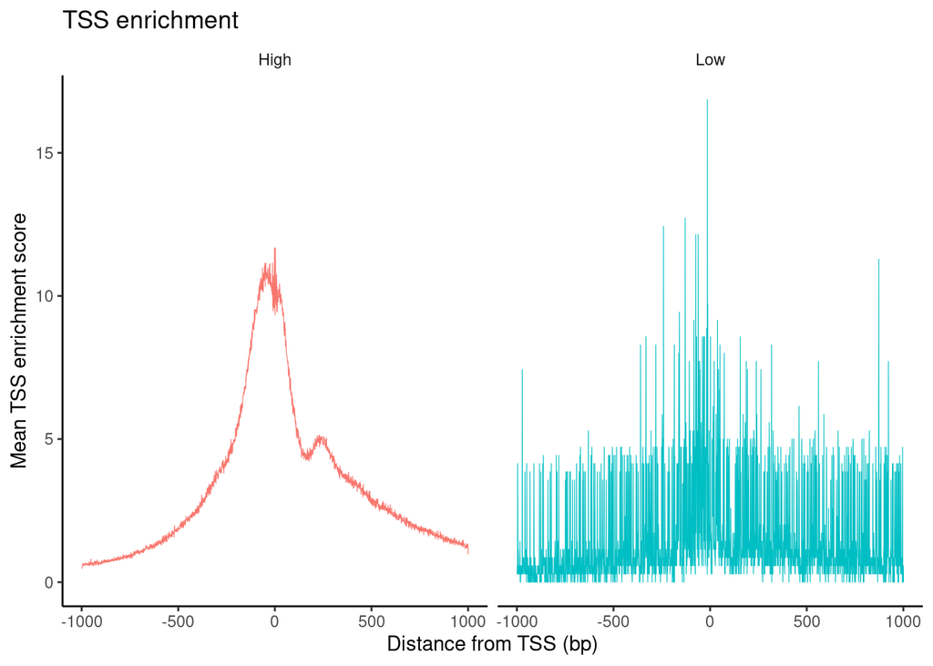

```r
pbmc$high.tss <- ifelse(pbmc$TSS.enrichment > 2, 'High', 'Low')
TSSPlot(pbmc, group.by = 'high.tss') + NoLegend()
```

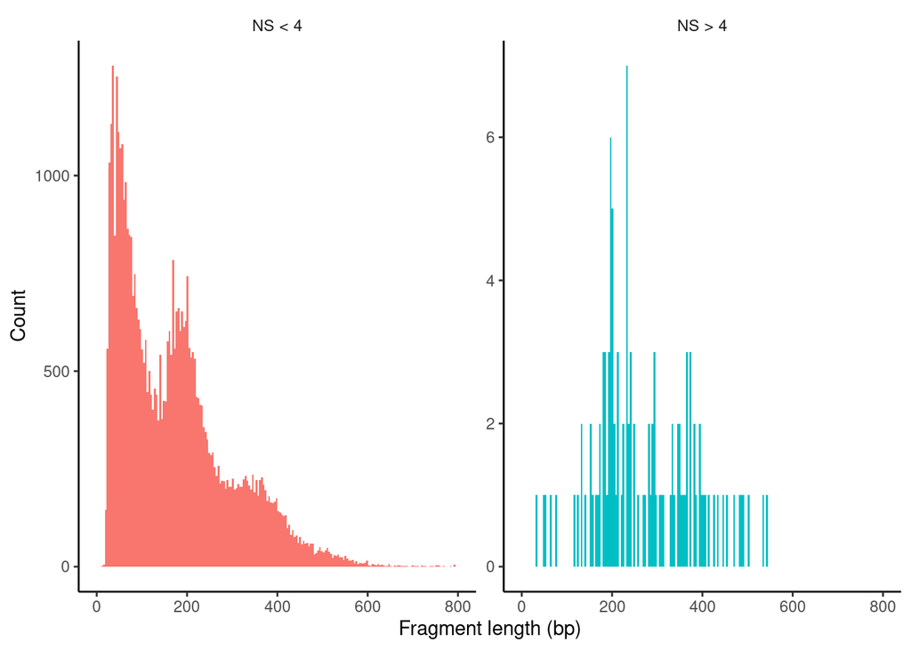

```r
pbmc$nucleosome_group <- ifelse(pbmc$nucleosome_signal > 4, 'NS > 4', 'NS < 4')
FragmentHistogram(object = pbmc, group.by = 'nucleosome_group')
```

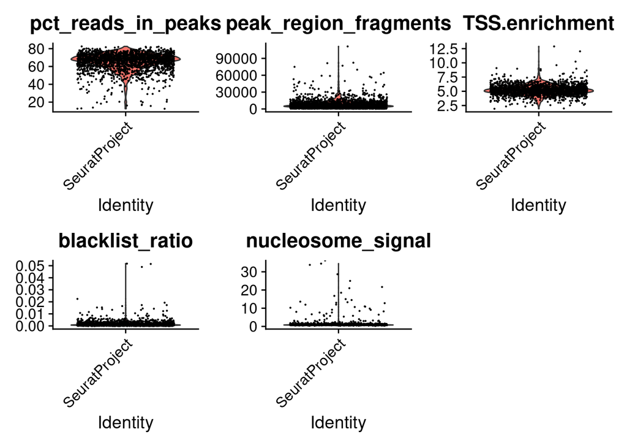

```r
VlnPlot(
    object = pbmc,
    features = c('pct_reads_in_peaks', 'peak_region_fragments',
                             'TSS.enrichment', 'blacklist_ratio', 'nucleosome_signal'),
    pt.size = 0.1,
    ncol = 3
)
```

After calculating the qualtiy statistics, we apply (some rather artibtrary) cutoffs, to remove outlier cells. *How many cells do we have left after quality filtering in this example?*

```r
pbmc <- subset(
    x = pbmc,
    subset = peak_region_fragments > 3000 &
        peak_region_fragments < 20000 &
        pct_reads_in_peaks > 15 &
        blacklist_ratio < 0.05 &
        nucleosome_signal < 4 &
        TSS.enrichment > 2
)
pbmc
```

```
## An object of class Seurat
## 75396 features across 1491 samples within 1 assay
## Active assay: peaks (75396 features, 0 variable features)
```

### Normalization and intial dimensionality reduction.

**Normalization:** Signac performs term frequency-inverse document frequency (TF-IDF) normalization. This is a two-step normalization procedure, often used in natural language processing, that both normalizes across cells to correct for differences in sequencing depth, and across peaks to give higher values to more rare peaks.

**Feature selection:** To reduce noise, we sometimes only use some features (i.e. peaks) when we cluster cells. Often this is the peaks with the strongest signal, i.e. most reasd, or the ones present in most cells. Here, we will use all peaks, but you can play around with this yourself. Try setting min.cutoff to ‘q75’ to use the top 25% peaks).

**Dimension reduction:** We next run singular value decomposition (SVD) on the normalized data matrix, using the features (peaks) selected above. This returns a reduced dimension representation of the matrix, similar to the output of PCA.

From the singular value decomposition, we get a set of components. The first of these components often correlates with seuquencing depth, rather than any biologically meaningful signal. We can therefore remove this component in the following analysis.

```r
pbmc <- RunTFIDF(pbmc)
```

```
## Performing TF-IDF normalization
```

```r
pbmc <- FindTopFeatures(pbmc, min.cutoff = 'q0')
pbmc <- RunSVD(pbmc)
```

```
## Running SVD
```

```
## Scaling cell embeddings
```

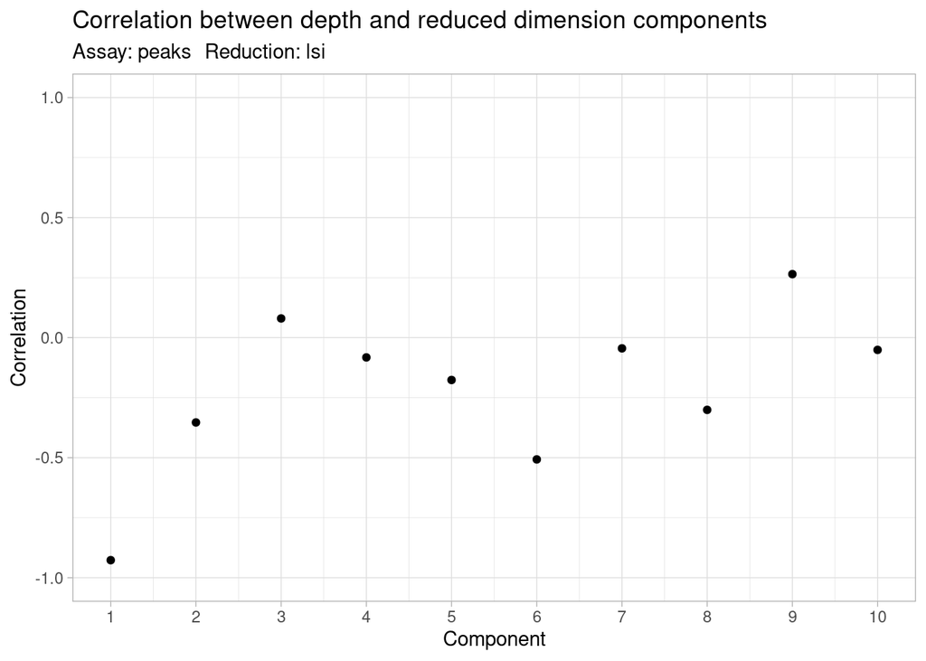

```r
DepthCor(pbmc)
```

### Clustering and further dimensionality reduction

Now we can cluster the cells to find groups that belong to the same cell types. It is possible to plot the results from the SVD, but these often are not informative. Instead, we use the UMAP algorithm, which shows a better separation between the cell types. If you are interested, the paper describing UMAP can be found [here](https://arxiv.org/abs/1802.03426)

```r
pbmc <- RunUMAP(object = pbmc, reduction = 'lsi', dims = 2:30)
pbmc <- FindNeighbors(object = pbmc, reduction = 'lsi', dims = 2:30)
```

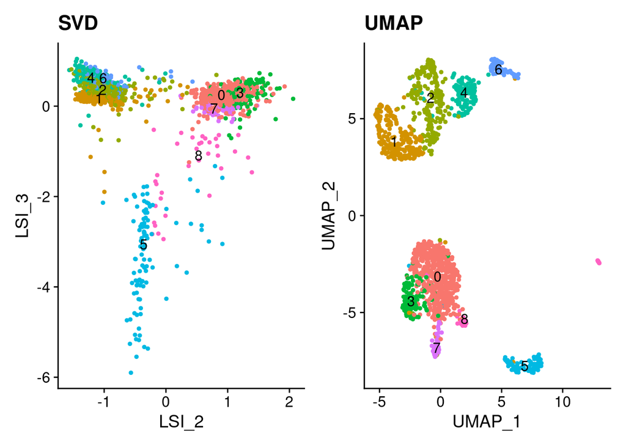

```r
pbmc <- FindClusters(object = pbmc, verbose = FALSE, algorithm = 3)

p1 <- DimPlot(object = pbmc, label = TRUE, dims = c(2, 3), reduction = "lsi") +
    NoLegend()  +
    ggtitle('SVD')

p2 <- DimPlot(object = pbmc, label = TRUE) +
    NoLegend() +
    ggtitle('UMAP')

p1 | p2
```

This might be a good time to save your data, so you don’t have to re-run all your analysis if you have problems with Uppmax or the network. To load the data later, type `load(file="pbmc.Rda")`.

```r
save(pbmc, file="pbmc.Rda")
```

### Motif analysis

We can also analyze motif occurence in the peaks, to see how this varies between the different cell types.

#### Identifying enriched motifs

First we will look at motifs that are enriched in set of peaks, e.g. in peaks that show differential accessibility between two cell types. *Do you notice anything particular about these motifs?*

```r
# Get a list of motif position frequency matrices from the JASPAR database
pfm <- getMatrixSet(
    x = JASPAR2020,
    opts = list(species = "Homo sapiens", all_versions = FALSE)
)

# Scan the DNA sequence of each peak for the presence of each motif
motif.matrix <- CreateMotifMatrix(
    features = granges(pbmc$peaks),
    pwm = pfm,
    genome = 'hg19',
    use.counts = FALSE
)
dim(motif.matrix)
```

```
## [1] 75396   633
```

```r
as.matrix(motif.matrix[1:10,1:10])
```

```
##                    MA0030.1 MA0031.1 MA0051.1 MA0057.1 MA0059.1 MA0066.1
## chr1-565113-565543        0        0        0        0        0        0
## chr1-569179-569635        0        0        0        0        0        0
## chr1-713534-714806        1        0        0        0        0        0
## chr1-752436-753020        0        0        0        0        0        0
## chr1-762144-763353        0        0        0        0        0        0
## chr1-779610-780252        0        0        0        0        0        1
## chr1-804934-805758        0        0        0        0        0        0
## chr1-839562-841087        0        0        0        1        0        0
## chr1-842027-842554        0        0        1        1        0        0
## chr1-856262-856894        0        0        0        0        0        0
##                    MA0069.1 MA0070.1 MA0071.1 MA0072.1
## chr1-565113-565543        0        1        0        0
## chr1-569179-569635        0        0        0        0
## chr1-713534-714806        0        0        0        1
## chr1-752436-753020        0        0        0        0
## chr1-762144-763353        0        0        0        0
## chr1-779610-780252        1        0        0        0
## chr1-804934-805758        0        0        0        0
## chr1-839562-841087        0        0        0        0
## chr1-842027-842554        0        0        0        0
## chr1-856262-856894        0        1        0        0
```

```r
# Create a new Mofif object to store the results
motif <- CreateMotifObject(
    data = motif.matrix,
    pwm = pfm
)

# Add the Motif object to the assay
pbmc <- SetAssayData(
    object = pbmc,
    assay = 'peaks',
    slot = 'motifs',
    new.data = motif
)
pbmc$peaks@motifs
```

```
## A Motif object containing 633 motifs in 75396 regions
```

```r
# Calculate statistics for each peak: GC content, length, dinucleotide frequencies etc.
# These are used in the test of motif enrichment
pbmc$peaks <- RegionStats(object = pbmc$peaks, genome = BSgenome.Hsapiens.UCSC.hg19)

# Find differentially accessible peaks in cluster 0 compared to cluster 1
da_peaks <- FindMarkers(
    object = pbmc,
    ident.1 = "0",
    ident.2 = "1",
    only.pos = TRUE,
    min.pct = 0.2,
    test.use = 'LR',
    latent.vars = 'peak_region_fragments'
)
# Get the top differentially accessible peaks, with lowest p-values
top.da.peak <- rownames(da_peaks[da_peaks$p_val < 1e-20, ])

# Find motifs enriched in these top differentially accessible peaks
enriched.motifs <- FindMotifs(
    object = pbmc,
    features = top.da.peak
)
```

```
## Selecting background regions to match input sequence characteristics
```

```
## Matching GC.percent distribution
```

```
## Testing motif enrichment in 613 regions
```

```r
head(enriched.motifs)
```

```
##             motif observed background percent.observed percent.background
## MA0476.1 MA0476.1      287       6411         46.81892            16.0275
## MA1141.1 MA1141.1      273       6085         44.53507            15.2125
## MA1634.1 MA1634.1      300       7287         48.93964            18.2175
## MA0462.2 MA0462.2      300       7332         48.93964            18.3300
## MA1128.1 MA1128.1      269       5959         43.88254            14.8975
## MA0489.1 MA0489.1      282       6563         46.00326            16.4075
##          fold.enrichment       pvalue motif.name
## MA0476.1        2.921162 1.603018e-72        FOS
## MA1141.1        2.927532 3.494192e-68  FOS::JUND
## MA1634.1        2.686408 3.849405e-68       BATF
## MA0462.2        2.669920 1.649413e-67  BATF::JUN
## MA1128.1        2.945631 1.746610e-67 FOSL1::JUN
## MA0489.1        2.803795 7.122879e-67 JUN(var.2)
```

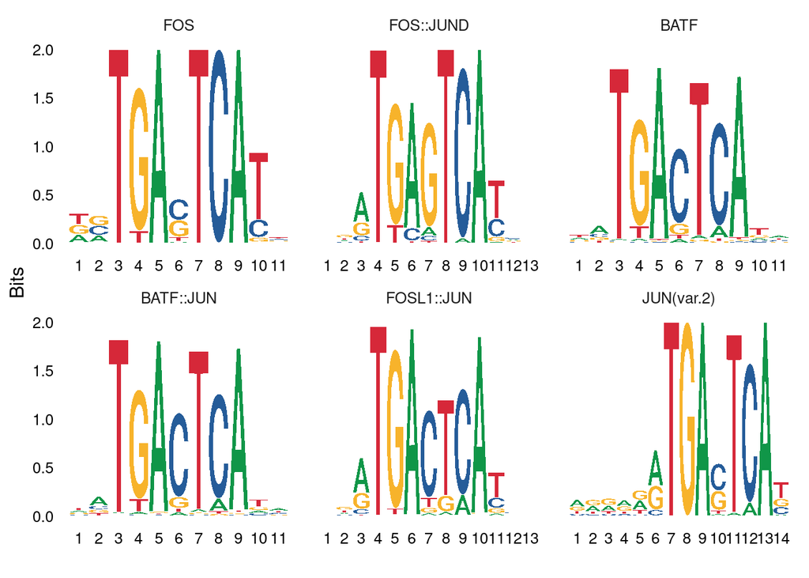

```r
# Have a look at the most enriched motifs. Do you anything particular about these motifs?
MotifPlot(
    object = pbmc,
    motifs = head(rownames(enriched.motifs))
)
```

#### Motif activity scores

We can also compute a per-cell motif activity score by running chromVAR. The motif activity score for a motif M is based on the on number of reads mapping to peaks with motif M, after normalization correction for various biases: GC content, average number of reads mapping across all cells etc. You can read more about chromVar [here](https://www.nature.com/articles/nmeth.4401). Motif activity scores allow us to visualize motif activities per cell.

It is also possible to directly test for differential activity scores between cell types, without looking at peaks with differential binding. This tends to give similar results as performing an enrichment test on differentially accessible peaks between the cell types (shown above).

This takes a while to run (around 5 minutes on Uppmax).

```r
# Use chromVAR to calculate the motif activities of all motifs in all cells.
pbmc <- RunChromVAR(
    object = pbmc,
    genome = BSgenome.Hsapiens.UCSC.hg19,
    verbose = TRUE
)
```

```
## Computing GC bias per region
```

```
## Selecting background regions
```

```
## Computing deviations from background
```

```
## Constructing chromVAR assay
```

```r
# Look at results
pbmc$chromvar
```

```
## Assay data with 633 features for 1491 cells
## First 10 features:
##  MA0030.1, MA0031.1, MA0051.1, MA0057.1, MA0059.1, MA0066.1, MA0069.1,
## MA0070.1, MA0071.1, MA0072.1
```

```r
GetAssayData(pbmc$chromvar)[1:10,1:3]
```

```
##          TCACCTGTCGCATACA-1 TGCATGAAGGCAAGGG-1 TATGTTCCACTCGTGG-1
## MA0030.1          0.4802596         -0.9263071         -1.6833813
## MA0031.1          3.0226959         -1.8794400         -1.8866870
## MA0051.1          0.9170732         -1.7235878         -2.6055429
## MA0057.1          0.3317284         -1.2583413         -1.1942476
## MA0059.1         -0.3215417         -0.9251217         -0.9129074
## MA0066.1         -1.2241029         -0.3185507          0.4136960
## MA0069.1          0.2697852         -0.8840232         -1.1968187
## MA0070.1          0.4910978         -0.4445854         -1.5875132
## MA0071.1          0.7344232         -0.7097084         -1.0799436
## MA0072.1         -0.3466114         -0.8838576         -1.2078881
```

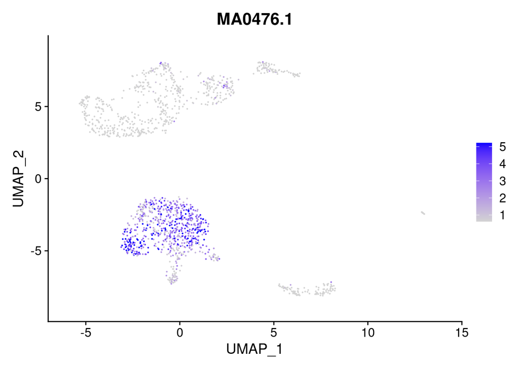

```r
# Have a look at the activitiy of the FOS motif, which has id MA0476.1
DefaultAssay(pbmc) <- 'chromvar'
FeaturePlot(
    object = pbmc,
    features = "MA0476.1",
    min.cutoff = 'q10',
    max.cutoff = 'q90',
    pt.size = 0.1
)
```

```r
# Look for motifs that have differential activity between clusters 0 and 1.
differential.activity <- FindMarkers(
    object = pbmc,
    ident.1 = '0',
    ident.2 = '1',
    only.pos = TRUE,
    test.use = 'LR',
    min.pct = 0.2,
    latent.vars = 'nCount_peaks'
)
```

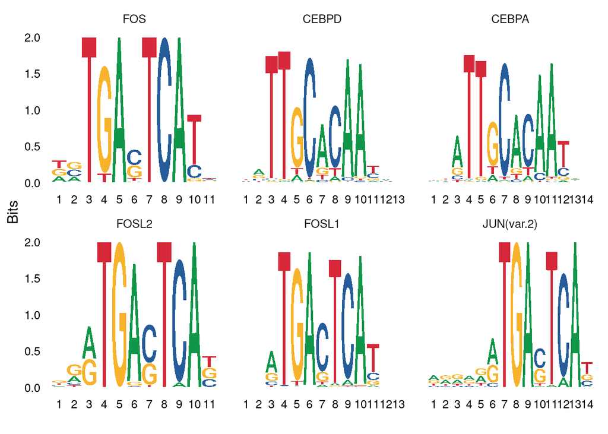

```r
MotifPlot(
  object = pbmc,
  motifs = head(rownames(differential.activity)),
  assay = 'peaks'
)
```

## Integrate with scRNA-seq data

In this section we will compare the scATAC-seq data to scRNA-seq data from a similar starting material (although not from exatcly the same cells). Since it is easier to figure out which cell types clusters correspond to in scRNA-seq data, we will then use the scRNA-seq data to annotate the clusters in the scATAC-seq data.

### Gene activity matrix

Gene activity scores capture how much open chromatin there is in the promoter regions of each gene (by defualt 2000bp upstream). The assumption here is that open chromatin is a proxy for gene expression. Gene activity scores are represented as a matrix, with one row per gene and one column per cell. This makes the gene activitiy scores directly compatible with single cell RNA-seq data.

Calculating the gene activity scores takes around 10 minutes for 2000 cells and all genes.

```r
DefaultAssay(pbmc) <- 'peaks'

gene.activities <- GeneActivity(pbmc)
```

```
## Extracting gene coordinates
```

```
## Extracting reads overlapping genomic regions
```

```r
# Add the gene activity matrix to the Seurat object as a new assay and normalize it
pbmc[['RNA']] <- CreateAssayObject(counts = gene.activities)
pbmc <- NormalizeData(
    object = pbmc,
    assay = 'RNA',
    normalization.method = 'LogNormalize',
    scale.factor = median(pbmc$nCount_RNA)
)
GetAssayData(pbmc$RNA)[1:10,1:3]
```

```
## 10 x 3 sparse Matrix of class "dgCMatrix"
##         TCACCTGTCGCATACA-1 TGCATGAAGGCAAGGG-1 TATGTTCCACTCGTGG-1
## PLCXD1           1.3601702          .                  0.8411336
## GTPBP6           .                  .                  .
## PPP2R3B          0.8954463          2.5325866          0.5065146
## SHOX             .                  .                  .
## CRLF2            .                  .                  .
## CSF2RA           .                  .                  0.5065146
## IL3RA            .                  .                  0.5065146
## SLC25A6          0.5447714          .                  0.8411336
## ASMTL            1.1545648          0.9764995          0.5065146
## P2RY8            1.3601702          1.7859823          0.5065146
```

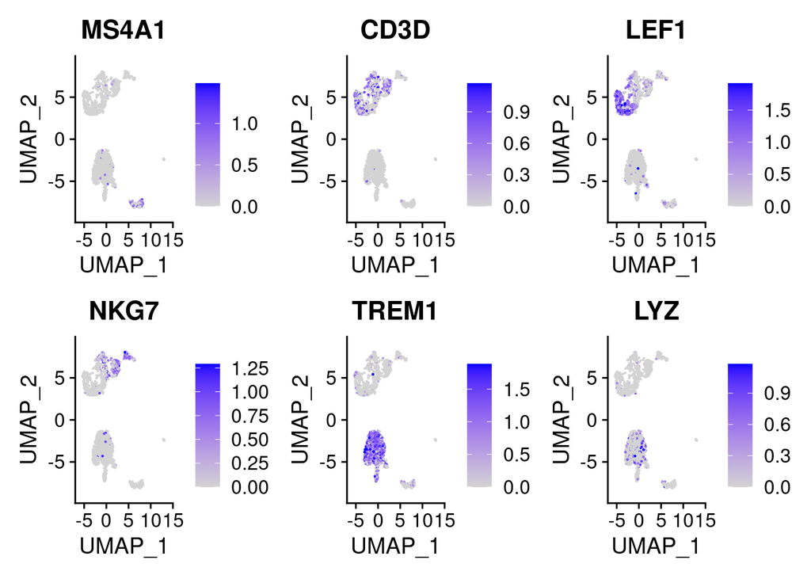

```r
DefaultAssay(pbmc) <- 'RNA'
FeaturePlot(
    object = pbmc,
    features = c('MS4A1', 'CD3D', 'LEF1', 'NKG7', 'TREM1', 'LYZ'),
    pt.size = 0.1,
    max.cutoff = 'q95',
    ncol = 3
)
```

### Label transfer

Having computed the gene activity scores, we are now ready to combine the ATAC-seq data with the RNA-seq data.

We start by finding anchors, i.e. paris of cells, one from ATAC-seq and one from RNA-seq. This is done by first projecting bort ATAC-seq and RNA-seq data into the same space, and then find pairs of cells one from ATAC-seq and the other from RNA-seq that are mutual nearest neighbors (MNNs). These are further filtered and the reliable pairs are the used as anchors.

These anchors can then be used to project the ATAC-seq data onto the RNA-seq data and find the cell type annotation of the nearby cells. This was annotations from the RNA-seq data can be transferred to the ATAC-seq data. This is sometimes referred to as **label transfer**

*How well do you think this worked? Can you see if some cells types are missing or merged?*

```r
# Load the pre-processed scRNA-seq data for PBMCs
pbmc_rna <- readRDS("pbmc_10k_v3.rds")

# Find anchors
transfer.anchors <- FindTransferAnchors(
    reference = pbmc_rna,
    query = pbmc,
    reduction = 'cca'
)
```

```
## Running CCA
```

```
## Merging objects
```

```
## Finding neighborhoods
```

```
## Finding anchors
```

```
##  Found 6757 anchors
```

```
## Filtering anchors
```

```
##  Retained 3076 anchors
```

```r
predicted.labels <- TransferData(
    anchorset = transfer.anchors,
    refdata = pbmc_rna$celltype,
    weight.reduction = pbmc[['lsi']],
    dims = 2:30
)
```

```
## Finding integration vectors
```

```
## Finding integration vector weights
```

```
## Predicting cell labels
```

```r
pbmc <- AddMetaData(object = pbmc, metadata = predicted.labels)
gc()
```

```
##             used   (Mb) gc trigger   (Mb)  max used   (Mb)
## Ncells  14188321  757.8   41370333 2209.5  68601112 3663.7
## Vcells 284045928 2167.1  594621239 4536.7 996843952 7605.4
```

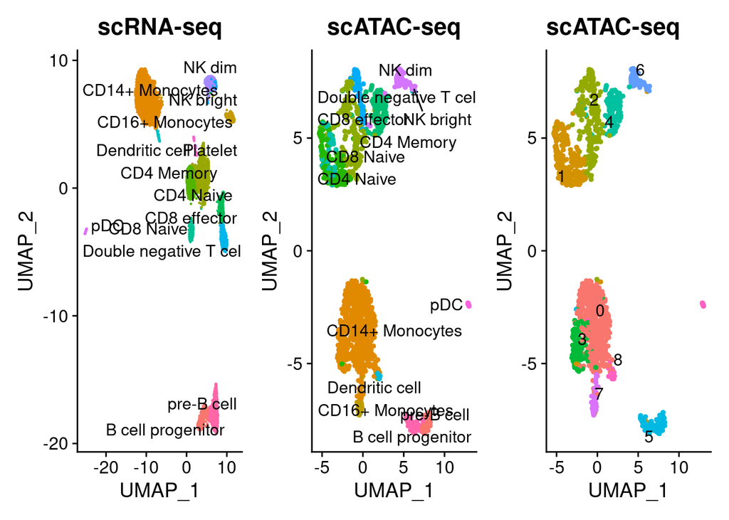

```r
plot1 <- DimPlot(
    object = pbmc_rna,
    group.by = 'celltype',
    label = TRUE,
    repel = TRUE) + NoLegend() + ggtitle('scRNA-seq')

plot2 <- DimPlot(
    object = pbmc,
    group.by = 'predicted.id',
    label = TRUE,
    repel = TRUE) + NoLegend() + ggtitle('scATAC-seq')

plot3 <- DimPlot(
  object = pbmc,
  label = TRUE,
  repel = TRUE) + NoLegend() + ggtitle('scATAC-seq')

plot1 | plot2 | plot3
```

```r
pbmc <- RenameIdents(
    object = pbmc,
    '0' = 'CD14 Mono',
    '1' = 'CD4/8 Naive',
    '2' = 'CD4 Memory (DN T)',
    '3' = 'CD14 Mono',
    '4' = 'CD8 Effector',
    '5' = 'pre-B/pro-B',
    '6' = 'NK dim',
    '7' = 'CD16 Mono',
    '8' = 'DC',
    '9' = 'pDC')
```

### Differentially accessible regions, again

Now, we will once again look at differentially accessible region, this time between CD4/8 Naive cells and CD14 Mono cells. (Since we now can say what cell types these clusters represent.) We can plot the signal in this region in a couple of different ways. *Do you understand what these plots mean?*

```r
# Change back to working with peaks instead of gene activities
DefaultAssay(pbmc) <- 'peaks'

# Find differentially acessible regions
da_peaks <- FindMarkers(
    object = pbmc,
    ident.1 = "CD4/8 Naive",
    ident.2 = "CD14 Mono",
    min.pct = 0.2,
    test.use = 'LR',
    latent.vars = 'peak_region_fragments'
)
```

[output not shown]

```r
head(da_peaks)
```

```
##                                   p_val avg_log2FC pct.1 pct.2    p_val_adj
## chr14-99726730-99741791   1.867510e-102  0.7684649 0.831 0.017 1.408028e-97
## chr6-44025145-44028164     1.341070e-78 -0.7638851 0.052 0.656 1.011113e-73
## chr14-23012898-23027991    2.141826e-76  0.6104493 0.848 0.120 1.614851e-71
## chr11-128334664-128347642  2.554129e-76  0.7632438 0.645 0.009 1.925711e-71
## chr17-80084212-80086050    8.350769e-76  0.9036165 0.667 0.009 6.296146e-71
## chr2-113581687-113594911   1.040308e-71 -0.7321783 0.069 0.670 7.843507e-67
```

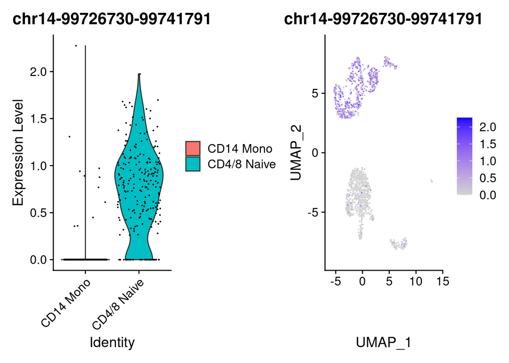

```r
# Plot the signal for the most differentially acessable region.
plot1 <- VlnPlot(
    object = pbmc,
    features = rownames(da_peaks)[1],
    pt.size = 0.1,
    idents = c("CD4/8 Naive","CD14 Mono")
)

plot2 <- FeaturePlot(
    object = pbmc,
    features = rownames(da_peaks)[1],
    pt.size = 0.1
)

plot1 | plot2
```

### Annotating regions

Genomic coordinates are difficult to interpret on their own, and often it is interesting to know which genes are near, or at, the genomic regions. Below we find the nearest gene, and the distance to it, for each region. This makes it easy to check for regions near genes of interest, and to analyze genes further, e.g though a Gene Ontology analysis.

```r
open_cd4naive <- rownames(da_peaks[da_peaks$avg_log2FC > 0.5, ])
open_cd14mono <- rownames(da_peaks[da_peaks$avg_log2FC < -0.5, ])

closest_genes_cd4naive <- ClosestFeature(pbmc, regions = open_cd4naive)
closest_genes_cd14mono <- ClosestFeature(pbmc, regions = open_cd14mono)
head(closest_genes_cd4naive)
```

```
##                           tx_id   gene_name         gene_id   gene_biotype type
## ENST00000443726 ENST00000443726      BCL11B ENSG00000127152 protein_coding  cds
## ENST00000557595 ENST00000557595 AE000662.92 ENSG00000259003 protein_coding  cds
## ENST00000535549 ENST00000535549        ETS1 ENSG00000134954 protein_coding  gap
## ENST00000583593 ENST00000583593      CCDC57 ENSG00000176155 protein_coding  cds
## ENST00000455990 ENST00000455990       HOOK1 ENSG00000134709 protein_coding  cds
## ENSE00002456092 ENST00000463701       PRSS1 ENSG00000204983 protein_coding exon
##                            closest_region              query_region distance
## ENST00000443726   chr14-99737498-99737555   chr14-99726730-99741791        0
## ENST00000557595   chr14-23027629-23027664   chr14-23012898-23027991        0
## ENST00000535549 chr11-128333523-128350085 chr11-128334664-128347642        0
## ENST00000583593   chr17-80085568-80085694   chr17-80084212-80086050        0
## ENST00000455990    chr1-60280790-60280852    chr1-60279775-60281328        0
## ENSE00002456092  chr7-142460719-142460923  chr7-142501957-142508028    41033
```

```r
head(closest_genes_cd14mono)
```

```
##                           tx_id     gene_name         gene_id   gene_biotype
## ENSE00001638912 ENST00000455005 RP5-1120P11.3 ENSG00000231881        lincRNA
## ENST00000432018 ENST00000432018          IL1B ENSG00000125538 protein_coding
## ENST00000445003 ENST00000445003 RP11-290F20.3 ENSG00000224397        lincRNA
## ENST00000568649 ENST00000568649         PPCDC ENSG00000138621 protein_coding
## ENST00000409245 ENST00000409245         TTC7A ENSG00000068724 protein_coding
## ENST00000396967 ENST00000396967          MAFB ENSG00000204103 protein_coding
##                 type           closest_region             query_region distance
## ENSE00001638912 exon   chr6-44041650-44042535   chr6-44025145-44028164    13485
## ENST00000432018  cds chr2-113593760-113593806 chr2-113581687-113594911        0
## ENST00000445003  gap  chr20-48884201-48894027  chr20-48889917-48893242        0
## ENST00000568649  cds  chr15-75335782-75335877  chr15-75334915-75336733        0
## ENST00000409245  cds   chr2-47300841-47301062   chr2-47298097-47301110        0
## ENST00000396967  cds  chr20-39316519-39317490  chr20-39315849-39319565        0
```

### Visualization

It is often informative to plot the ATAC-seq signal for a particular genomic region, and group this by cluster, cell type or some other meta data. We can either plot the the aggregate signal for a group with `coveragePlot` or the signal for individual cells, with `tilePlot`. More info about plotting genomic region can be found [here](https://satijalab.org/signac/articles/visualization.html)

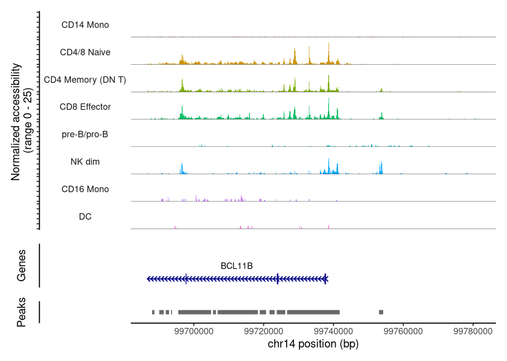

```r
CoveragePlot(
    object = pbmc,
    region = rownames(da_peaks)[1],
    extend.upstream = 40000,
    extend.downstream = 40000,
    peaks=TRUE
)
```

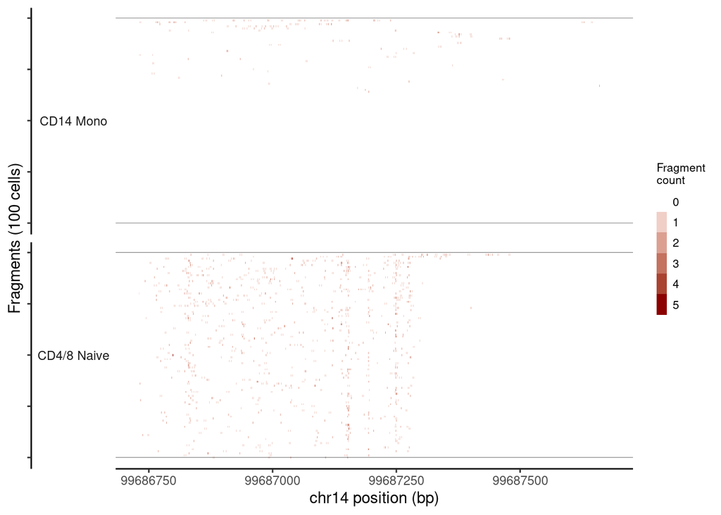

```r
TilePlot(
    object = pbmc,
    region = rownames(da_peaks)[1],
    idents = c('CD14 Mono', 'CD4/8 Naive'),
    extend.upstream = 40000,
    extend.downstream = 40000
)
```